# Codebook for summary

## fBodyGyro-std()-X

| Feature | Result |
| --- | --- |
| Variable type | numeric |
| Number of missing obs. | 0 (0 %) |
| Number of unique values | 180 |
| Median | -0.81 |
| 1st and 3rd quartiles | -0.98; -0.48 |
| Min. and max. | -0.99; 0.2 |

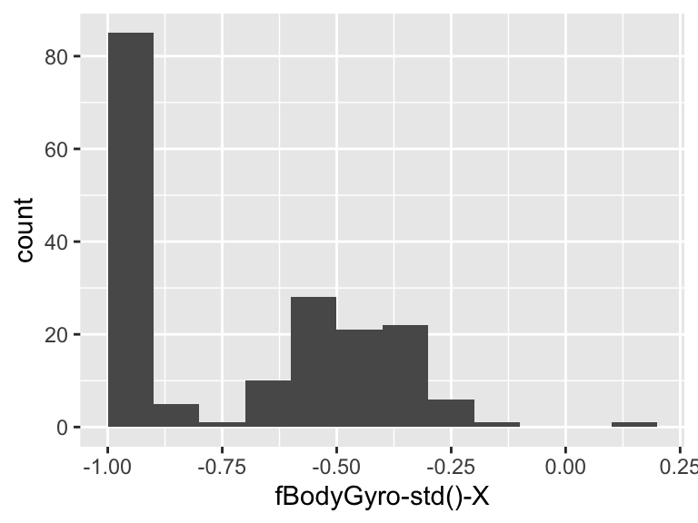

## fBodyGyro-std()-Y

| Feature | Result |
| --- | --- |
| Variable type | numeric |
| Number of missing obs. | 0 (0 %) |
| Number of unique values | 180 |
| Median | -0.8 |
| 1st and 3rd quartiles | -0.96; -0.42 |
| Min. and max. | -0.99; 0.65 |

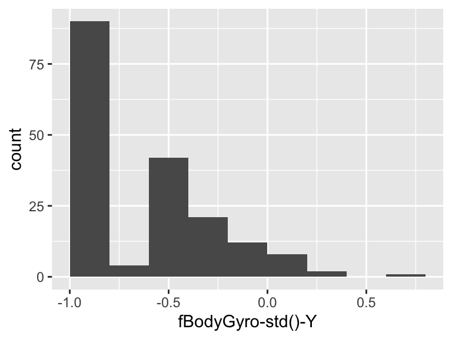

## fBodyGyro-std()-Z

| Feature | Result |
| --- | --- |
| Variable type | numeric |
| Number of missing obs. | 0 (0 %) |
| Number of unique values | 180 |
| Median | -0.82 |
| 1st and 3rd quartiles | -0.96; -0.39 |
| Min. and max. | -0.99; 0.52 |

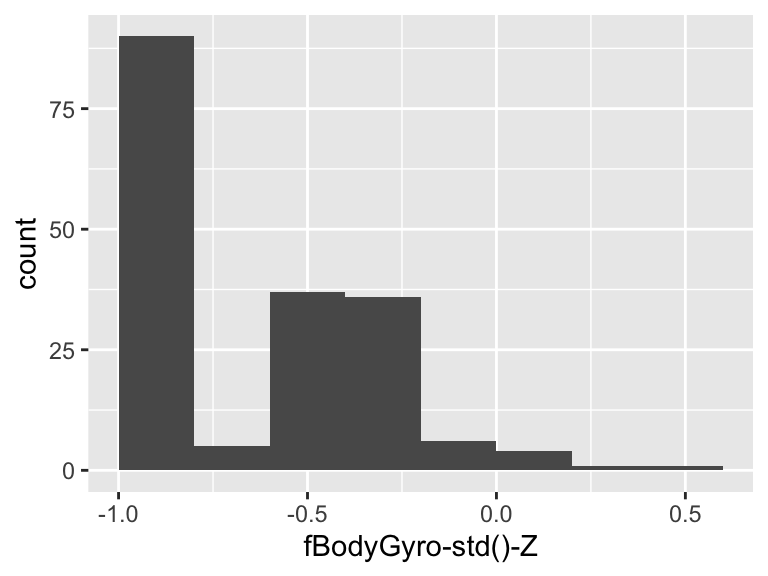

## fBodyGyro-meanFreq()-X

| Feature | Result |
| --- | --- |
| Variable type | numeric |
| Number of missing obs. | 0 (0 %) |
| Number of unique values | 180 |
| Median | -0.12 |
| 1st and 3rd quartiles | -0.21; 0 |
| Min. and max. | -0.4; 0.25 |

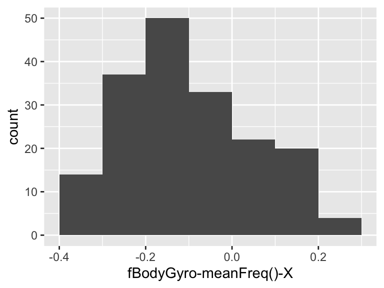

## fBodyGyro-meanFreq()-Y

| Feature | Result |
| --- | --- |
| Variable type | numeric |
| Number of missing obs. | 0 (0 %) |
| Number of unique values | 180 |
| Median | -0.16 |
| 1st and 3rd quartiles | -0.29; -0.04 |
| Min. and max. | -0.67; 0.27 |

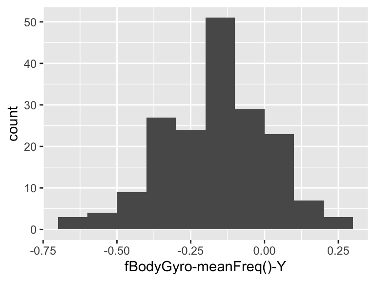

## fBodyGyro-meanFreq()-Z

| Feature | Result |
| --- | --- |
| Variable type | numeric |
| Number of missing obs. | 0 (0 %) |
| Number of unique values | 180 |
| Median | -0.05 |
| 1st and 3rd quartiles | -0.15; 0.04 |
| Min. and max. | -0.51; 0.38 |

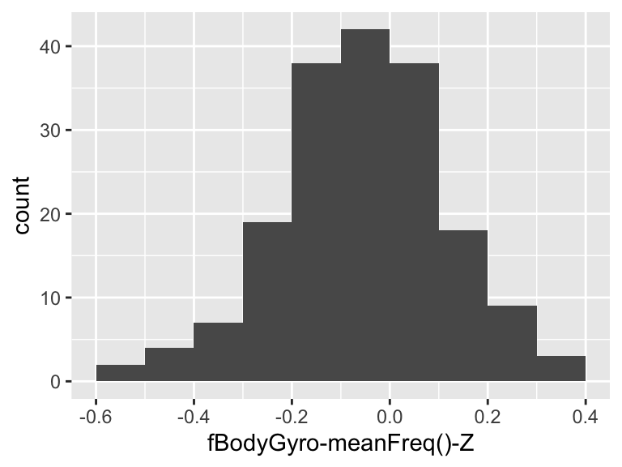

## fBodyAccMag-mean()

| Feature | Result |
| --- | --- |
| Variable type | numeric |
| Number of missing obs. | 0 (0 %) |
| Number of unique values | 180 |
| Median | -0.67 |
| 1st and 3rd quartiles | -0.96; -0.16 |
| Min. and max. | -0.99; 0.59 |

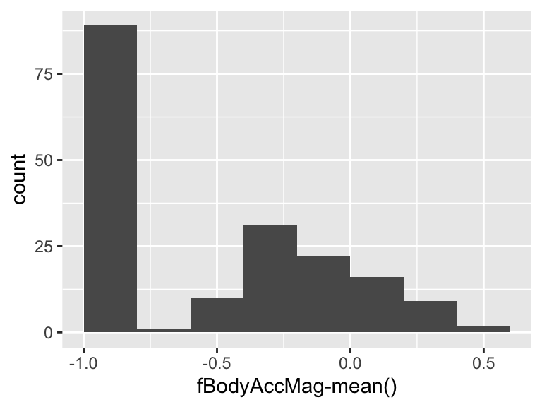

## fBodyAccMag-std()

| Feature | Result |
| --- | --- |
| Variable type | numeric |
| Number of missing obs. | 0 (0 %) |
| Number of unique values | 180 |
| Median | -0.65 |
| 1st and 3rd quartiles | -0.95; -0.37 |
| Min. and max. | -0.99; 0.18 |

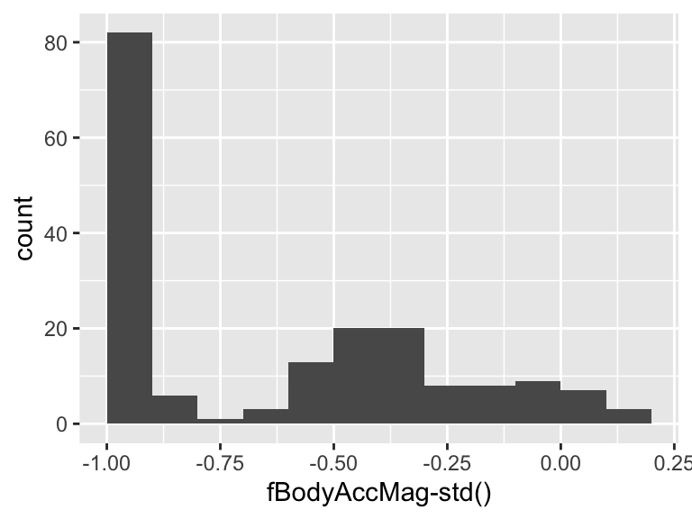

## fBodyAccMag-meanFreq()

| Feature | Result |
| --- | --- |
| Variable type | numeric |
| Number of missing obs. | 0 (0 %) |
| Number of unique values | 180 |
| Median | 0.08 |
| 1st and 3rd quartiles | -0.01; 0.17 |
| Min. and max. | -0.31; 0.44 |

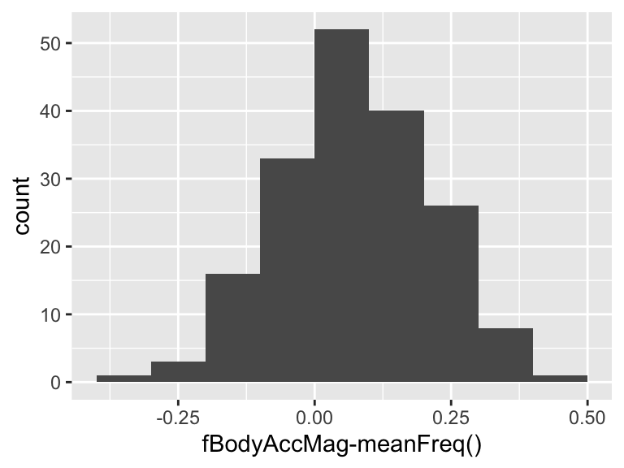

## fBodyBodyAccJerkMag-mean()

| Feature | Result |
| --- | --- |
| Variable type | numeric |
| Number of missing obs. | 0 (0 %) |
| Number of unique values | 180 |
| Median | -0.79 |
| 1st and 3rd quartiles | -0.98; -0.19 |
| Min. and max. | -0.99; 0.54 |

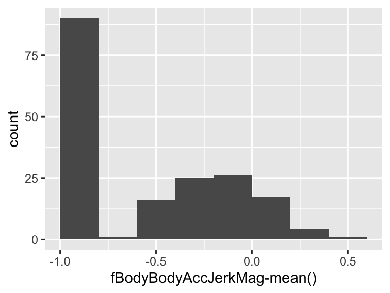

## fBodyBodyAccJerkMag-std()

| Feature | Result |
| --- | --- |
| Variable type | numeric |
| Number of missing obs. | 0 (0 %) |
| Number of unique values | 180 |
| Median | -0.81 |
| 1st and 3rd quartiles | -0.98; -0.27 |
| Min. and max. | -0.99; 0.32 |

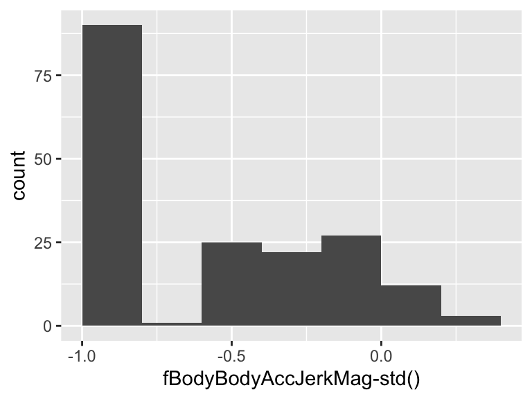

## fBodyBodyAccJerkMag-meanFreq()

| Feature | Result |
| --- | --- |
| Variable type | numeric |
| Number of missing obs. | 0 (0 %) |
| Number of unique values | 180 |
| Median | 0.17 |
| 1st and 3rd quartiles | 0.05; 0.28 |
| Min. and max. | -0.13; 0.49 |

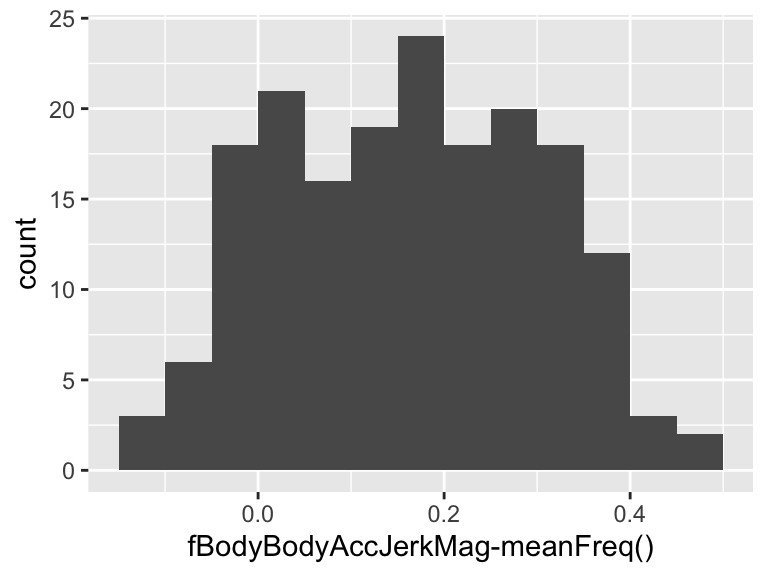

## fBodyBodyGyroMag-mean()

| Feature | Result |
| --- | --- |
| Variable type | numeric |
| Number of missing obs. | 0 (0 %) |
| Number of unique values | 180 |
| Median | -0.77 |
| 1st and 3rd quartiles | -0.96; -0.41 |
| Min. and max. | -0.99; 0.2 |

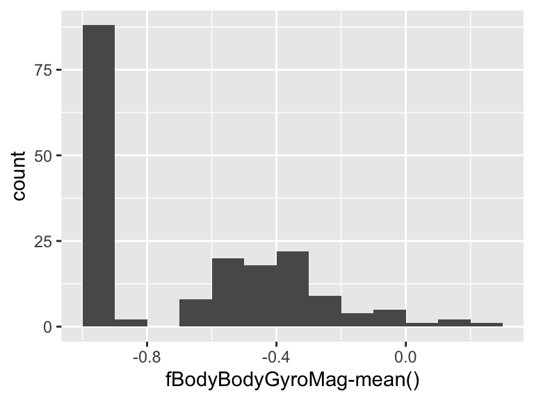

## fBodyBodyGyroMag-std()

| Feature | Result |
| --- | --- |
| Variable type | numeric |
| Number of missing obs. | 0 (0 %) |
| Number of unique values | 180 |
| Median | -0.77 |
| 1st and 3rd quartiles | -0.95; -0.43 |
| Min. and max. | -0.98; 0.24 |

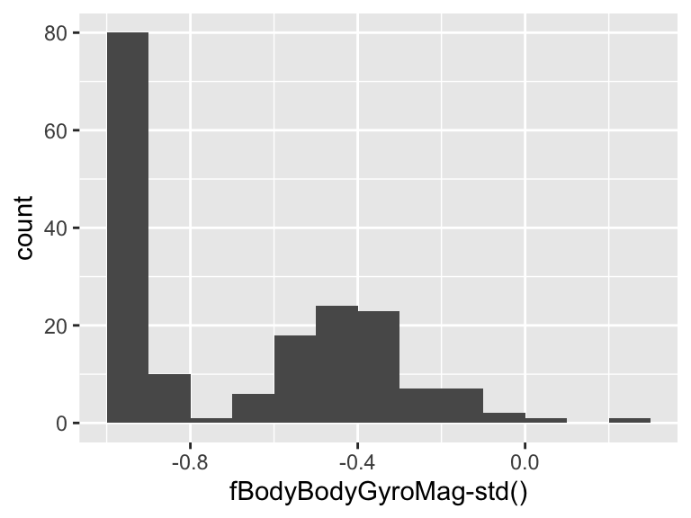

## fBodyBodyGyroMag-meanFreq()

| Feature | Result |
| --- | --- |
| Variable type | numeric |
| Number of missing obs. | 0 (0 %) |
| Number of unique values | 180 |
| Median | -0.05 |
| 1st and 3rd quartiles | -0.17; 0.08 |
| Min. and max. | -0.46; 0.41 |

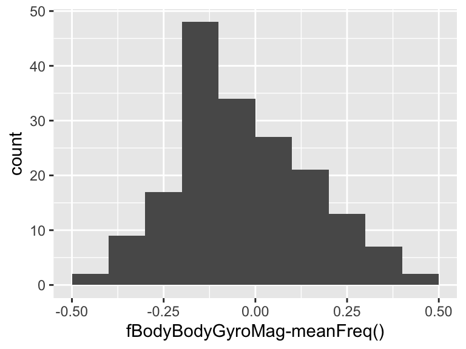

## fBodyBodyGyroJerkMag-mean()

| Feature | Result |
| --- | --- |
| Variable type | numeric |
| Number of missing obs. | 0 (0 %) |
| Number of unique values | 180 |
| Median | -0.88 |
| 1st and 3rd quartiles | -0.98; -0.58 |
| Min. and max. | -1; 0.15 |

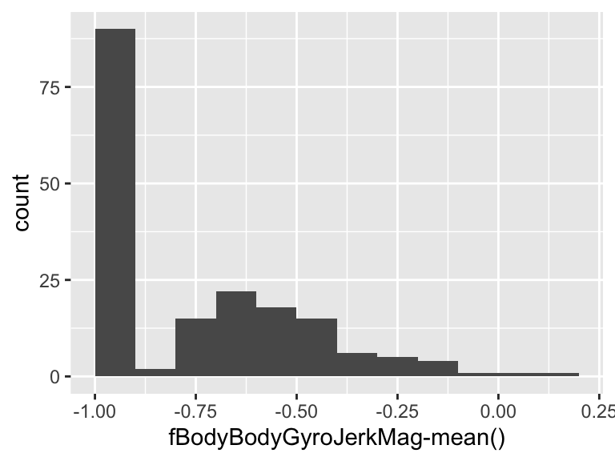

## fBodyBodyGyroJerkMag-std()

| Feature | Result |
| --- | --- |
| Variable type | numeric |
| Number of missing obs. | 0 (0 %) |
| Number of unique values | 180 |
| Median | -0.89 |
| 1st and 3rd quartiles | -0.98; -0.61 |
| Min. and max. | -1; 0.29 |

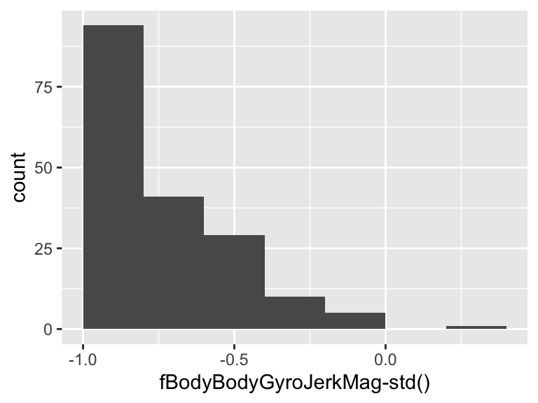

## fBodyBodyGyroJerkMag-meanFreq()

| Feature | Result |
| --- | --- |
| Variable type | numeric |
| Number of missing obs. | 0 (0 %) |
| Number of unique values | 180 |
| Median | 0.11 |
| 1st and 3rd quartiles | 0.05; 0.21 |
| Min. and max. | -0.18; 0.43 |

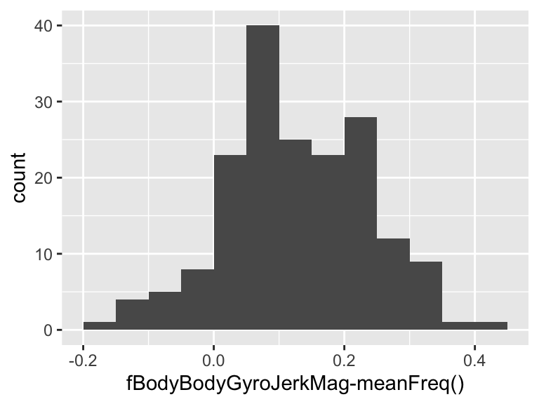

Report generation information:

- Created by: Gareth Coffey (username: `garethcoffey`).
- Report creation time: Sun Apr 26 2020 14:15:49
- Report was run from directory: `/Users/garethcoffey/Documents/RStudio/Getting and Cleaning Data/Week 4/CleaningData-Week4-Assignment`
- dataMaid v1.4.0 [Pkg: 2019-12-10 from CRAN (R 3.6.0)]
- R version 3.6.3 (2020-02-29).
- Platform: x86_64-apple-darwin15.6.0 (64-bit)(macOS Catalina 10.15.4).
- Function call: `dataMaid::makeDataReport(data = summary, mode = c("summarize", "visualize", "check"), smartNum = FALSE, file = "codebook_summary.Rmd", checks = list(character = "showAllFactorLevels", factor = "showAllFactorLevels", labelled = "showAllFactorLevels", haven_labelled = "showAllFactorLevels", numeric = NULL, integer = NULL, logical = NULL, Date = NULL), listChecks = FALSE, maxProbVals = Inf, codebook = TRUE, reportTitle = "Codebook for summary")`